# Herramientas para el Análisis de Series de Tiempo en R - Ejercitación 2

Oficina de la CEPAL en Buenos Aires

Octubre 2021

# Objetivos

# Ejercitación clase 2: elasticidad ingreso de las importaciones

### Paso 1: librerías

Empezamos limpiando la memoria, cargando las librerías y estableciendo el directorio. En esta ejercitación agregamos `kableExtra`, para personalizar el formato de las tablas.

```r
##  Limpiar la memoria
rm(list=ls())

## Apertura de librerias
library(tidyverse)  #Manejo de bases de datos y otros
library(openxlsx)   #Lectura de xlsx
library(lubridate)  #Manejo de variables en formato fecha
library(zoo)        #Series de tiempo
library(forecast)   #Pronosticos
library(ggfortify)  #Graficos
library(kableExtra) #Formato tablas

## Establecemos el directorio, recordar cambiar las \ por /
setwd("C:/Users/Garlan/Desktop/CEPAL/Curso Series")

options(scipen=9999) #Evita que los resultados se impriman en notación científica
```

Vamos a comparar una especificación donde regresamos las importaciones contra el PIB, con una donde incluimos al TCR como variable de control.

### Pasos 2 a 5: cargar e inspeccionar los datos, definir fecha y ajustar frecuencia

Cargamos `Clase 2.xlsx`, que tiene los niveles de importaciones, PIB y TCR para el período 2004-2021, usando `read.xlsx()`. En este caso hacemos la inspección en Excel. Las importaciones y el PIB desestacionalizados a precios constantes, en la hoja “PIB”, surgen del Sistema de Cuentas Nacionales ([INDEC](https://www.indec.gob.ar/indec/web/Nivel4-Tema-3-9-47)) y ya están en frecuencia trimestral. Declaramos la fecha con `as.Date()` y extraemos año (`year()`) y trimestre (`quarter()`) para juntar las bases más adelante.

```r
scn <- read.xlsx("Clase 2.xlsx",sheet = 'PIB') %>%
  mutate(Fecha = as.Date(Fecha, origin = "1899-12-30"),
         year = year(Fecha),
         quarter = quarter(Fecha))
```

El TCRM del [BCRA](http://www.bcra.gob.ar/PublicacionesEstadisticas/Indices_tipo_cambio_multilateral.asp), en cambio, está disponible en frecuencia diaria, por lo que calculamos el promedio trimestral.

- Declaramos la fecha y extraemos año y trimestre.
- Agrupamos por año y trimestre (`group_by()`).
- Calculamos el promedio de cada grupo (`summarise()`) y desagrupamos (`ungroup()`).

```r
tcr <- read.xlsx("Clase 2.xlsx",sheet = 'TCR') %>%
  mutate(Fecha = as.Date(Fecha, origin = "1899-12-30"),
         year = year(Fecha),
         quarter = quarter(Fecha)) %>%
  group_by(year, quarter) %>%
  summarise(TCR = mean(TCR)) %>%
  ungroup()
```

### Paso 6: unir las bases

Finalmente, juntamos ambas bases en el data.frame `df` mediante `left_join()`.

```r
df <- scn %>%
  left_join(tcr, by = c("year", "quarter"))
```

Tomemos 5 o 10’ para correr el código hasta acá, crear las variables en logaritmos y regresar `lM` sobre `lPIB` y sobre `lPIB + lTCR`.

$$log M_t=\alpha_0+\alpha_1 \ logPIB_t +\epsilon_t$$
$$log M_t=\beta_0+\beta_1 \ logPIB_t + \beta_2 \ logTCR_t +\varepsilon_t$$

## Estimación

### Pasos 7 y 8: transformaciones y gráfico

Usando `mutate()`, creamos las variables en niveles logarítmicos y convertimos todo a series de tiempo.

- La función `across()` (dentro de mutate) permite aplicar una misma función a variables variables.
- `everything()` establece que se aplique a todas.
- `.fns` es el parámetro donde especificamos la función que queremos aplicar. Y luego, separados por `,`, podemos pasar los parámetros de la función que estamos aplicando (en este caso, los parámetros de `ts()`).

```r
df <- df %>%
  mutate(lPIB = log(PIB),
         lM = log(M),
         lTCR = log(TCR),
         across(everything(), .fns = ts, start = c(2004,1), frequency = 4))
```

Finlamente inspeccionamos las series en un `autoplot()`. Como vimos en la ejercitación anterior, aplicando `attach()` sobre un data.frame podemos evitar indicar qué data.frame queremos usar cada vez que nombramos una variable (como haríamos en Stata). Ahora podemos referirnos a las variables dentro de `df` por su nombre, como si fueran objetos.

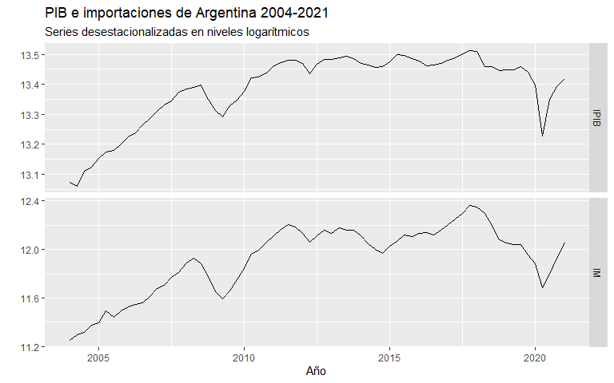

```r
attach(df)
autoplot(cbind(lPIB,lM), facets=TRUE)+
  labs(y = "", x = "Año",
       title = "PIB e importaciones de Argentina 2004-2021",
       subtitle = "Series desestacionalizadas en niveles logarítmicos")
```

### Paso 10: estimación

Para la estimación usamos `tslm()`, que econométricamente es idéntica a `lm()` pero permite

- preservar el formato `ts` en el modelo e
- introducir transformaciones (por ejemplo, logs) directamente en la especificación.

Entonces, podemos estimar el modelo utilizando las variables en niveles logarítmicos que creamos en el paso anterior, o podríamos haber salteado ese paso y directamente incluir los logs dentro de la ecuación.

```r
modelo1 <- tslm(lM ~ lPIB)          #Para escribir ~ podemos usar Alt+126
modelo1 <- tslm(log(M) ~ log(PIB))  #Idéntico a la linea anterior

modelo2 <- tslm(lM ~ lPIB + lTCR)
```

La función `summary()` devuelve toda la información necesaria: signo y magnitud de los coeficientes, significatividad estadística de los coeficientes, restricción de exclusión, etc.

```r
summary(modelo1)
```

```
##
## Call:
## tslm(formula = log(M) ~ log(PIB))
##
## Residuals:
##       Min        1Q    Median        3Q       Max
## -0.121324 -0.055612 -0.001343  0.043390  0.205939
##
## Coefficients:
##              Estimate Std. Error t value            Pr(>|t|)
## (Intercept) -19.08915    0.99078  -19.27 <0.0000000000000002 ***
## log(PIB)      2.31630    0.07401   31.30 <0.0000000000000002 ***
## ---
## Signif. codes:  0 '***' 0.001 '**' 0.01 '*' 0.05 '.' 0.1 ' ' 1
##
## Residual standard error: 0.07205 on 67 degrees of freedom
## Multiple R-squared:  0.936,  Adjusted R-squared:  0.935
## F-statistic: 979.6 on 1 and 67 DF,  p-value: < 0.00000000000000022
```

```r
summary(modelo2)
```

```
##
## Call:
## tslm(formula = lM ~ lPIB + lTCR)
##
## Residuals:
##       Min        1Q    Median        3Q       Max
## -0.144818 -0.045274 -0.002659  0.039253  0.191737
##
## Coefficients:
##              Estimate Std. Error t value             Pr(>|t|)
## (Intercept) -14.54363    1.71810  -8.465      0.0000000000039 ***
## lPIB          2.04359    0.11109  18.396 < 0.0000000000000002 ***
## lTCR         -0.18645    0.05924  -3.148              0.00247 **
## ---
## Signif. codes:  0 '***' 0.001 '**' 0.01 '*' 0.05 '.' 0.1 ' ' 1
##
## Residual standard error: 0.06769 on 66 degrees of freedom
## Multiple R-squared:  0.9443, Adjusted R-squared:  0.9427
## F-statistic: 559.9 on 2 and 66 DF,  p-value: < 0.00000000000000022
```

- En la primera especificación la elasticidad ingreso de las importaciones es de 2.3. El coeficiente tiene el signo y magnitud esperados, y es estadísticamente significativo.
- En el segundo modelo tanto el PIB como el TCR son estadísticamente significativos y sus coeficientes tienen el signo esperado: un aumento del producto implica un mayor volumen de importaciones (efecto ingreso) y un aumento del tipo de cambio real determina un menor volumen (efecto precio).
- La inclusión del TCR como variable de control reduce la elasticidad a 2. La magnitud del coeficiente es baja, de -0.19, e indica que una depreciación real del 10% implica una caída de de las importaciones de -1.9%, para un mismo nivel de PIB.
- En esta segunda especificación, un crecimiento del PIB de 1% trae asociado un aumento de las importaciones de 2%, lo cual, tomando el nivel de importaciones de 2019, implica un aumento de la demanda de divisas de aproximadamente USD 1360 M.

Con `names()` accedemos a la información disponible dentro del objeto (similar a *return list* en Stata). Podemos llamar esos nombres (por ejemplo, *coefficients*) para acceder a la información, ya sea usando `$` o mediante funciones específicas, como `coef()`.

```r
names(modelo2)
```

```
##  [1] "coefficients"  "residuals"     "effects"       "rank"
##  [5] "fitted.values" "assign"        "qr"            "df.residual"
##  [9] "xlevels"       "call"          "terms"         "model"
## [13] "data"          "x"             "method"
```

```r
modelo2$coefficients
```

```
## (Intercept)        lPIB        lTCR
## -14.5436323   2.0435929  -0.1864514
```

```r
coef(modelo2)
```

```
## (Intercept)        lPIB        lTCR
## -14.5436323   2.0435929  -0.1864514
```

También podemos acceder a información más detallada dentro de `summary`, y guardar, por ejemplo, el p-valor del coeficiente del PIB en el modelo 2.

```r
names(summary(modelo1))
```

```
##  [1] "call"          "terms"         "residuals"     "coefficients"
##  [5] "aliased"       "sigma"         "df"            "r.squared"
##  [9] "adj.r.squared" "fstatistic"    "cov.unscaled"
```

```r
summary(modelo2)$coefficients
```

```
##                Estimate Std. Error   t value                           Pr(>|t|)
## (Intercept) -14.5436323 1.71809939 -8.464954 0.00000000000390266753886149946615
## lPIB          2.0435929 0.11108672 18.396375 0.00000000000000000000000000111484
## lTCR         -0.1864514 0.05923508 -3.147652 0.00247072808108421719183733777925
```

```r
p_value_pib_mod2 <- summary(modelo2)$coefficients[2,4]
p_value_pib_mod2
```

```
## [1] 0.00000000000000000000000000111484
```

## Criterios de información

### Paso 11: selección del modelo

Finalmente, usamos criterios bondad de ajuste para comparar los modelos en términos de su ajuste a los datos, complementando el análisis de significatividad parcial. La función `CV()` (paquete `forecast`) permite calcular los criterios de información automáticamente.

```r
CV(modelo1)
```

```
##             CV            AIC           AICc            BIC          AdjR2
##    0.005390541 -359.015406322 -358.646175553 -352.313086809    0.935029821
```

```r
CV(modelo2)
```

```
##             CV            AIC           AICc            BIC          AdjR2
##    0.004814968 -366.665992039 -366.040992039 -357.729566021    0.942654023
```

Para presentar los resultados armamos una tabla. Primero creamos manualmente un data.frame que indique qué variables incluye cada modelo, con `rename()` establecemos los nombres de las columnas y con `cbind()` (por *column bind*) agregamos las columnas con los criterios. Con `rbind()` (por *row bind*) estamos pegando uno arriba de otro los criterios de cada modelo. Finalmente, `kable()` del paquete `kableExtra` permite darle formato a la tabla.

```r
bondad_ajuste <- data.frame(c(1,1),c(0,1)) %>%
                              rename("PIB"=1,"TCR"=2) %>%
                              cbind(rbind(CV(modelo1),CV(modelo2)))
row.names(bondad_ajuste) <- c("Modelo 1", "Modelo 2")

kable(bondad_ajuste, align=rep('c', 7)) %>%  #Centrar las 7 columnas
  kable_styling(bootstrap_options = c("striped", "hover"), #Formato de filas
                font_size = 14) #Tamaño de letra
```

|  | PIB | TCR | CV | AIC | AICc | BIC | AdjR2 |
| --- | --- | --- | --- | --- | --- | --- | --- |
| Modelo 1 | 1 | 0 | 0.0053905 | -359.0154 | -358.6462 | -352.3131 | 0.9350298 |
| Modelo 2 | 1 | 1 | 0.0048150 | -366.6660 | -366.0410 | -357.7296 | 0.9426540 |

# Consigna para la clase 3: elasticidad empleo-producto

Vamos a estimar la elasticidad-producto del empleo. Para eso:

1. Cargar datos de empleo y PIB desde `Clase 3.xlsx` (la serie de empleo es distinta a la que construimos hoy).
2. Crear las variables en logaritmos.
3. Regresar el empleo sobre el producto, y sobre el producto y el tipo de cambio (todo en logaritmos).
4. Computar los criterios de información.